Data Science Fundamentals: R | Table of Contents

Module 15. tidyverse | R Markdown | R + Shiny App | Basic Visualization | Tibbles | ggplot2 | Statistical Transformations | Exercises

[figure not shown]

# Exercises

The [original exercises and data](http://rstudio-pubs-static.s3.amazonaws.com/284329_c7e660636fec4a42a09eed968dc47f32.html) for all the exercises is also available locally here `./dataSets/EconomistData.csv`

```r
library(ggplot2)
library(readr)
```

```r
dat <- read_csv("dataSets/EconomistData.csv")
dat
```

| Country | HDI.Rank | HDI | CPI | Region |
| --- | --- | --- | --- | --- |
| Afghanistan | 172 | 0.398 | 1.5 | Asia Pacific |
| Albania | 70 | 0.739 | 3.1 | East EU Cemt Asia |
| Algeria | 96 | 0.698 | 2.9 | MENA |
| Angola | 148 | 0.486 | 2.0 | SSA |
| Argentina | 45 | 0.797 | 3.0 | Americas |
| Armenia | 86 | 0.716 | 2.6 | East EU Cemt Asia |
| Australia | 2 | 0.929 | 8.8 | Asia Pacific |
| Austria | 19 | 0.885 | 7.8 | EU W. Europe |
| Azerbaijan | 91 | 0.700 | 2.4 | East EU Cemt Asia |
| Bahamas | 53 | 0.771 | 7.3 | Americas |
| Bahrain | 42 | 0.806 | 5.1 | MENA |
| Bangladesh | 146 | 0.500 | 2.7 | Asia Pacific |
| Barbados | 47 | 0.793 | 7.8 | Americas |
| Belarus | 65 | 0.756 | 2.4 | East EU Cemt Asia |
| Belgium | 18 | 0.886 | 7.5 | EU W. Europe |
| Benin | 167 | 0.427 | 3.0 | SSA |
| Bhutan | 141 | 0.522 | 5.7 | Asia Pacific |
| Bolivia | 108 | 0.663 | 2.8 | Americas |
| Bosnia and Herzegovina | 74 | 0.733 | 3.2 | East EU Cemt Asia |
| Botswana | 118 | 0.633 | 6.1 | SSA |
| Brazil | 84 | 0.718 | 3.8 | Americas |
| Britain | 28 | 0.863 | 7.8 | EU W. Europe |
| Bulgaria | 55 | 0.771 | 3.3 | EU W. Europe |
| Burkina Faso | 181 | 0.331 | 3.0 | SSA |
| Burundi | 185 | 0.316 | 1.9 | SSA |
| Cambodia | 139 | 0.523 | 2.1 | Asia Pacific |
| Cameroon | 150 | 0.482 | 2.5 | SSA |
| Canada | 6 | 0.908 | 8.7 | Americas |
| Cape Verde | 133 | 0.568 | 5.5 | SSA |
| Central African Republic | 179 | 0.343 | 2.2 | SSA |
| ... | ... | ... | ... | ... |
| South Africa | 123 | 0.619 | 4.1 | SSA |
| Spain | 23 | 0.878 | 6.2 | EU W. Europe |
| Sri Lanka | 97 | 0.691 | 3.3 | Asia Pacific |
| Sudan | 169 | 0.408 | 1.6 | SSA |
| Suriname | 104 | 0.680 | 3.0 | Americas |
| Swaziland | 140 | 0.522 | 3.1 | SSA |
| Sweden | 10 | 0.904 | 9.3 | EU W. Europe |
| Switzerland | 11 | 0.903 | 8.8 | EU W. Europe |
| Syria | 119 | 0.632 | 2.6 | MENA |
| Tajikistan | 127 | 0.607 | 2.3 | East EU Cemt Asia |
| Tanzania | 152 | 0.466 | 3.0 | SSA |
| Thailand | 103 | 0.682 | 3.4 | Asia Pacific |
| Timor-Leste | 147 | 0.495 | 2.4 | Asia Pacific |
| Togo | 162 | 0.435 | 2.4 | SSA |
| Tonga | 90 | 0.704 | 3.1 | Asia Pacific |
| Trinidad and Tobago | 62 | 0.760 | 3.2 | Americas |
| Tunisia | 94 | 0.698 | 3.8 | MENA |
| Turkey | 92 | 0.699 | 4.2 | East EU Cemt Asia |
| Turkmenistan | 102 | 0.686 | 1.6 | East EU Cemt Asia |
| Uganda | 161 | 0.446 | 2.4 | SSA |
| Ukraine | 76 | 0.729 | 2.3 | East EU Cemt Asia |
| United Arab Emirates | 30 | 0.846 | 6.8 | MENA |
| United States | 4 | 0.910 | 7.1 | Americas |
| Uruguay | 48 | 0.783 | 7.0 | Americas |
| Uzbekistan | 115 | 0.641 | 1.6 | East EU Cemt Asia |
| Vanuatu | 125 | 0.617 | 3.5 | Asia Pacific |
| Venezuela | 73 | 0.735 | 1.9 | Americas |
| Yemen | 154 | 0.462 | 2.1 | MENA |
| Zambia | 164 | 0.430 | 3.2 | SSA |
| Zimbabwe | 173 | 0.376 | 2.2 | SSA |

```r
dat$Region <- factor(dat$Region,
                     levels = c("EU W. Europe",
                                "Americas",
                                "Asia Pacific",
                                "East EU Cemt Asia",
                                "MENA",
                                "SSA"),
                     labels = c("OECD",
                                "Americas",
                                "Asia &\nOceania",
                                "Central &\nEastern Europe",
                                "Middle East &\nnorth Africa",
                                "Sub-Saharan\nAfrica"))
```

### Exercise 1.

These data consist of Human Development Index and Corruption Perception Index scores for several countries.

- A. Create a scatter plot with CPI on the x axis and HDI on the y axis.
- B. Color the points blue.
- C. Map the color of the the points to Region.
- D. Make the points bigger by setting size to 2
- E. Map the size of the points to HDI.Rank

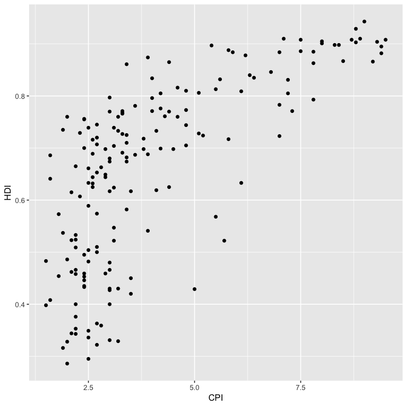

```r
# Create a scatter plot with CPI on the x axis and HDI on the y axis.

ggplot(dat, aes(x=CPI,y=HDI)) + geom_point()
```

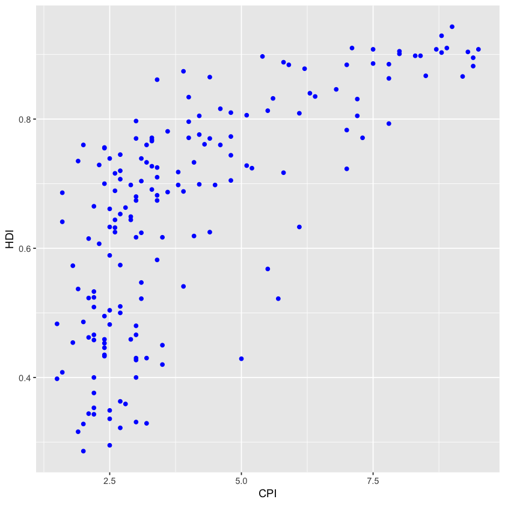

```r
#Color the points blue
ggplot(dat, aes(x=CPI,y=HDI)) + geom_point(color='blue')
```

```r
#Map the color of the the points to Region
ggplot(dat, aes(x=CPI,y=HDI, color=clarity, shape=cut)) + geom_point() + facet_wrap(~ cut)
```

[output not shown]

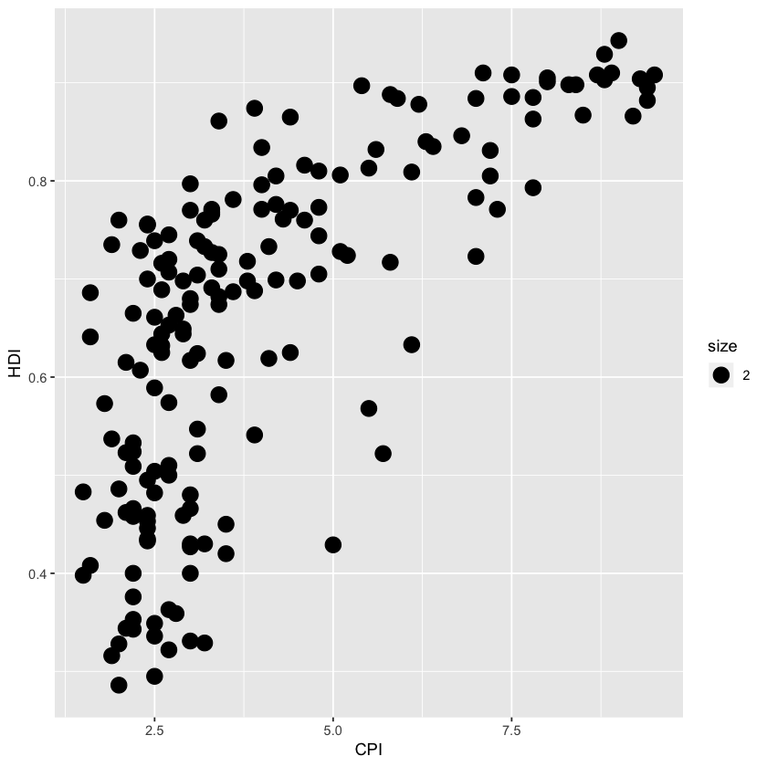

```r
# Make the points bigger by setting size to 2
ggplot(dat, aes(x=CPI,y=HDI, size=2)) + geom_point()
```

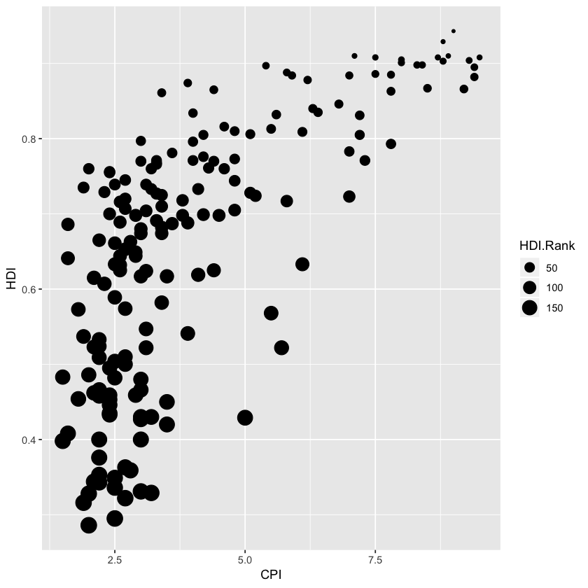

```r
# Map the size of the points to HDI.Rank
ggplot(dat, aes(x = CPI, y = HDI)) +
  geom_point(aes(size = HDI.Rank))
```

### Exercise 2.

- A. Re-create a scatter plot with CPI on the x axis and HDI on the y axis (as you did in the previous exercise).
- B. Overlay a smoothing line on top of the scatter plot using `geom_smooth`.
- C. Overlay a smoothing line on top of the scatter plot using `geom_smooth`, but use a linear model for the predictions. Hint: see `?stat_smooth`.
- D. Overlay a smoothing line on top of the scatter plot using `geom_line`. Hint: change the statistical transformation.
- **BONUS**: Overlay a smoothing line on top of the scatter plot using the default loess method, but make it less smooth. Hint: see `?loess`.

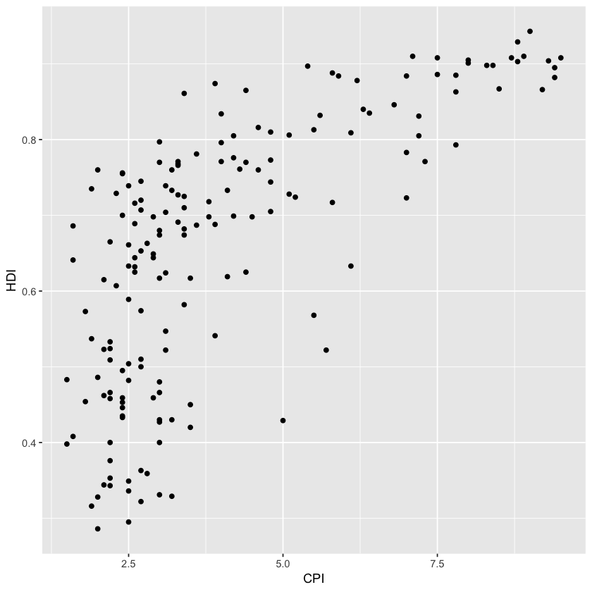

```r
#A. Re-create a scatter plot with CPI on the x axis and HDI on the y axis (as you did in the previous exercise).
ggplot(dat, aes(x = CPI, y = HDI)) + geom_point()
```

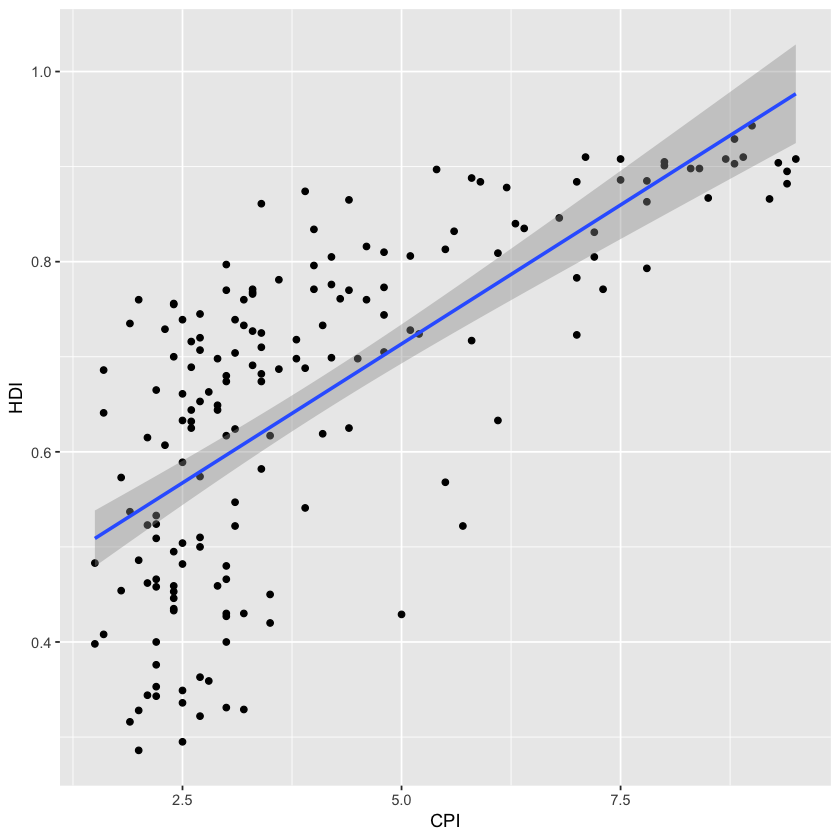

```r
#B. Overlay a smoothing line on top of the scatter plot using geom_smooth.
ggplot(dat, aes(x = CPI, y = HDI)) + geom_point() + geom_smooth(method=lm)
```

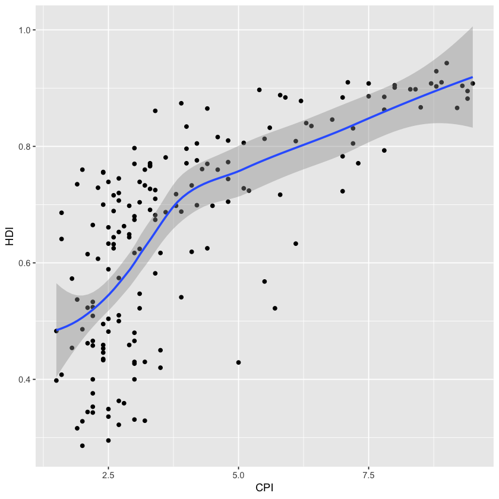

```r
# Overlay a smoothing line on top of the scatter plot using geom_smooth,
# but use a linear model for the predictions. Hint: see stat_smooth.
ggplot(dat, aes(x = CPI, y = HDI)) + geom_point() + stat_smooth()
```

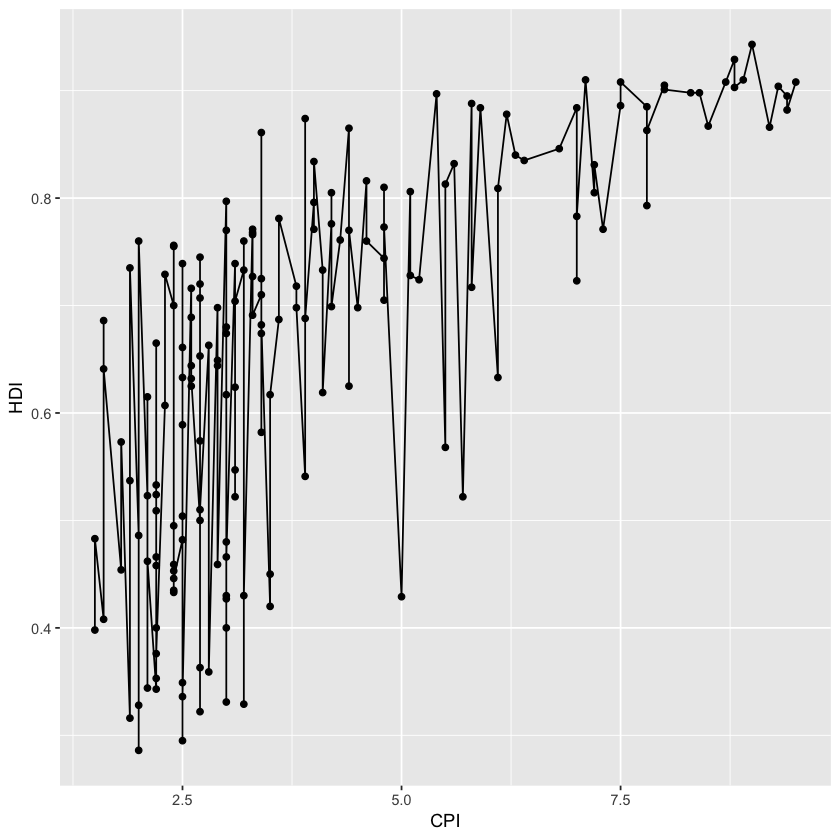

```r
# Overlay a smoothing line on top of the scatter plot using geom_line.
# Hint: change the statistical transformation
ggplot(dat, aes(x = CPI, y = HDI)) + geom_point() + geom_line()
```

[figure not shown]

```r
# **BONUS**: Overlay a smoothing line on top of the scatter plot using the
# default loess method, but make it less smooth. Hint: see ?loess
```

### Exercise 3.

- A. Create a scatter plot with CPI on the x axis and HDI on the y axis. Color the points to indicate region.
- B. Modify the x, y, and color scales so that they have more easily-understood names (e.g., spell out “Human development Index” instead of “HDI”).
- C. Modify the color scale to use specific values of your choosing. Hint: see `?scale_color_manual`.

[figure not shown]

```r
# Create a scatter plot with CPI on the x axis and HDI on the y axis. Color the points to indicate region
ggplot(dat, aes(x = CPI, y = HDI, color= Region)) + geom_point()
```

[figure not shown]

```r
# Modify the x, y, and color scales so that they have more easily-understood names
# (e.g., spell out “Human development Index” instead of “HDI”).
x <- ggplot(dat, aes(x = CPI, y = HDI, color= Region)) + geom_point()

print(x + labs(y = "Curruption Index", x = "Human Development Index"))
```

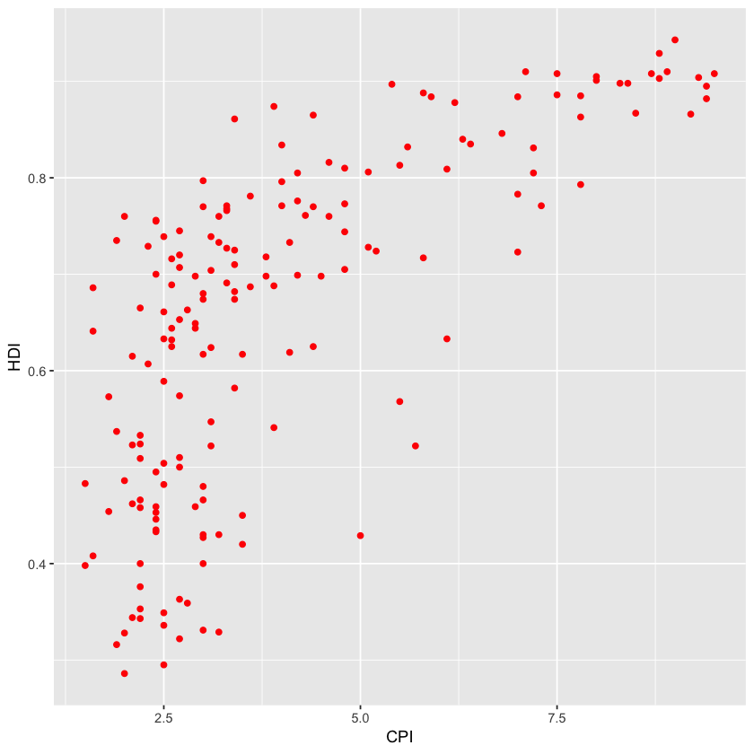

```r
# Modify the color scale to use specific values of your choosing. Hint: see scale_color_manual.
x <- ggplot(dat, aes(x = CPI, y = HDI)) + geom_point(color="red")
x
```